**City College of San Francisco**

MATH 108 - Foundations of Data Science

# Lecture 06: Tables

Associated Textbook Sections: [3.4](https://inferentialthinking.com/chapters/03/4/Introduction_to_Tables.html)

## Overview

- Tables
- Table Properties
- Some Table Functions

## Set Up the Notebook

```python
from datascience import *
import numpy as np
```

## Tables

### Table Structure

- A `Table` is a sequence of labeled columns
- Each row represents one individual
- Data within a column represents one attribute of the individuals

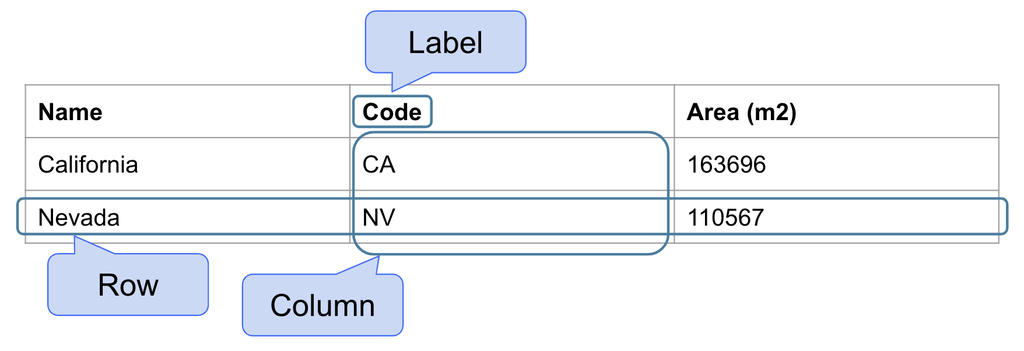

### Demo: Tables

Import and explore the data in `states_area.csv` (source: [Wikipedia](https://en.wikipedia.org/wiki/List_of_U.S._states_and_territories_by_area)) using `read_table`, `show`, `select`, `drop`, `where`, and `sort.

```python
# Empty tables are created using Table() function from datascience library.
# We use the table method .read_table to import a .csv file.

states = Table.read_table('./data/states_area.csv')
states
```

| State | Total Area (sq mi) | Land Area (sq mi) | Water Area (sq mi) |
| --- | --- | --- | --- |
| Alaska | 665384 | 570641 | 94743.1 |
| Texas | 268596 | 261232 | 7364.75 |
| California | 163695 | 155779 | 7915.52 |
| Montana | 147040 | 145546 | 1493.91 |
| New Mexico | 121590 | 121298 | 292.15 |
| Arizona | 113990 | 113594 | 396.22 |
| Nevada | 110572 | 109781 | 790.65 |
| Colorado | 104094 | 103642 | 451.78 |
| Oregon | 98378.5 | 95988 | 2390.53 |
| Wyoming | 97813 | 97093.1 | 719.87 |

... (40 rows omitted)

```python
type(states)
```

```
datascience.tables.Table
```

## Table Properties

There are several properties about a table that you can extract directly from a table:

- `t.labels` - the labels of a table called `t`
- `t.num_columns` - the number of columns of a table
- `t.num_rows` - the number of rows of a table
- `t.rows` - a collection of all the rows in a table

### Demo: Table Attributes

There are various properties of a table that you can access as well using the dot notation such as `labels`, `num_columns`, and `num_rows`.

```python
# labels gets the labels on the top of the columns

states.labels
```

```
('State', 'Total Area (sq mi)', 'Land Area (sq mi)', 'Water Area (sq mi)')
```

```python
# number of columns

states.num_columns
```

```
4
```

```python
# number of rows

states.num_rows
```

```
50
```

```python
# a collection of all the rows in a table

states.rows
```

```
Rows(State      | Total Area (sq mi) | Land Area (sq mi) | Water Area (sq mi)
Alaska     | 665384             | 570641            | 94743.1
Texas      | 268596             | 261232            | 7364.75
California | 163695             | 155779            | 7915.52
Montana    | 147040             | 145546            | 1493.91
New Mexico | 121590             | 121298            | 292.15
Arizona    | 113990             | 113594            | 396.22
Nevada     | 110572             | 109781            | 790.65
Colorado   | 104094             | 103642            | 451.78
Oregon     | 98378.5            | 95988             | 2390.53
Wyoming    | 97813              | 97093.1           | 719.87
... (40 rows omitted))
```

## Some Table Functions

There is a collection of functions associated with `Table` data types.

- `t.show(n)` - displays the first `n` rows of a table called `t`
- `t.select(label)` - constructs a new table with just the specified columns
- `t.drop(label)` - constructs a new table in which the specified columns are omitted
- `t.sort(label)` - constructs a new table with rows sorted by the specified column
- `t.where(label, condition)` - constructs a new table with just the rows that match the condition
- More can be found in the [`datascience` documentation](https://datascience.readthedocs.io/en/master/tables.html)

### Demo: `show`

```python
states.show(5)
```

| State | Total Area (sq mi) | Land Area (sq mi) | Water Area (sq mi) |
| --- | --- | --- | --- |
| Alaska | 665384 | 570641 | 94743.1 |
| Texas | 268596 | 261232 | 7364.75 |
| California | 163695 | 155779 | 7915.52 |
| Montana | 147040 | 145546 | 1493.91 |
| New Mexico | 121590 | 121298 | 292.15 |

... (45 rows omitted)

```python
states.show()
```

| State | Total Area (sq mi) | Land Area (sq mi) | Water Area (sq mi) |
| --- | --- | --- | --- |
| Alaska | 665384 | 570641 | 94743.1 |
| Texas | 268596 | 261232 | 7364.75 |
| California | 163695 | 155779 | 7915.52 |
| Montana | 147040 | 145546 | 1493.91 |
| New Mexico | 121590 | 121298 | 292.15 |
| Arizona | 113990 | 113594 | 396.22 |
| Nevada | 110572 | 109781 | 790.65 |
| Colorado | 104094 | 103642 | 451.78 |
| Oregon | 98378.5 | 95988 | 2390.53 |
| Wyoming | 97813 | 97093.1 | 719.87 |
| Michigan | 96713.5 | 56538.9 | 40174.6 |
| Minnesota | 86935.8 | 79626.7 | 7309.09 |
| Utah | 84896.9 | 82169.6 | 2727.26 |
| Idaho | 83568.9 | 82643.1 | 925.83 |
| Kansas | 82278.4 | 81758.7 | 519.64 |
| Nebraska | 77347.8 | 76824.2 | 523.64 |
| South Dakota | 77115.7 | 75811 | 1304.68 |
| Washington | 71297.9 | 66455.5 | 4842.43 |
| North Dakota | 70698.3 | 69000.8 | 1697.52 |
| Oklahoma | 69898.9 | 68594.9 | 1303.95 |
| Missouri | 69707 | 68741.5 | 965.47 |
| Florida | 65757.7 | 53624.8 | 12132.9 |
| Wisconsin | 65496.4 | 54157.8 | 11338.6 |
| Georgia | 59425.2 | 57513.5 | 1911.66 |
| Illinois | 57913.6 | 55518.9 | 2394.62 |
| Iowa | 56272.8 | 55857.1 | 415.68 |
| New York | 54555 | 47126.4 | 7428.58 |
| North Carolina | 53819.2 | 48617.9 | 5201.25 |
| Arkansas | 53178.6 | 52035.5 | 1143.07 |
| Alabama | 52420.1 | 50645.3 | 1774.74 |
| Louisiana | 52378.1 | 43203.9 | 9174.23 |
| Mississippi | 48431.8 | 46923.3 | 1508.51 |
| Pennsylvania | 46054.3 | 44742.7 | 1311.64 |
| Ohio | 44825.6 | 40860.7 | 3964.89 |
| Virginia | 42774.9 | 39490.1 | 3284.84 |
| Tennessee | 42144.2 | 41234.9 | 909.36 |
| Kentucky | 40407.8 | 39486.3 | 921.46 |
| Indiana | 36419.6 | 35826.1 | 593.44 |
| Maine | 35379.7 | 30842.9 | 4536.82 |
| South Carolina | 32020.5 | 30060.7 | 1959.79 |
| West Virginia | 24230 | 24038.2 | 191.83 |
| Maryland | 12405.9 | 9707.24 | 2698.69 |
| Hawaii | 10931.7 | 6422.63 | 4509.09 |
| Massachusetts | 10554.4 | 7800.06 | 2754.33 |
| Vermont | 9616.36 | 9216.66 | 399.71 |
| New Hampshire | 9349.16 | 8952.65 | 396.51 |
| New Jersey | 8722.58 | 7354.22 | 1368.36 |
| Connecticut | 5543.41 | 4842.36 | 701.06 |
| Delaware | 2488.72 | 1948.54 | 540.18 |
| Rhode Island | 1544.89 | 1033.81 | 511.07 |

```python
# show(3) does not produce a Table. It's just a display feature.

states_show_3 = states.show(3)
type(states_show_3)
```

| State | Total Area (sq mi) | Land Area (sq mi) | Water Area (sq mi) |
| --- | --- | --- | --- |
| Alaska | 665384 | 570641 | 94743.1 |
| Texas | 268596 | 261232 | 7364.75 |
| California | 163695 | 155779 | 7915.52 |

... (47 rows omitted)

```
NoneType
```

### Demo: `select`

Select columns using column labels and column indexes.

```python
states.select('State', 'Total Area (sq mi)')   # This can be used to create a new table.
```

| State | Total Area (sq mi) |
| --- | --- |
| Alaska | 665384 |
| Texas | 268596 |
| California | 163695 |
| Montana | 147040 |
| New Mexico | 121590 |
| Arizona | 113990 |
| Nevada | 110572 |
| Colorado | 104094 |
| Oregon | 98378.5 |
| Wyoming | 97813 |

... (40 rows omitted)

```python
# can use column indices instead. Will do the same thing as using the labels.

states.select(0, 1)
```

| State | Total Area (sq mi) |
| --- | --- |
| Alaska | 665384 |
| Texas | 268596 |
| California | 163695 |
| Montana | 147040 |
| New Mexico | 121590 |
| Arizona | 113990 |
| Nevada | 110572 |
| Colorado | 104094 |
| Oregon | 98378.5 |
| Wyoming | 97813 |

... (40 rows omitted)

```python
# A NameError where the column name was used incorrectly. Needs to be in quotes.

states.select(State, 'Total Area (sq mi)')
```

```
---------------------------------------------------------------------------
NameError                                 Traceback (most recent call last)
Cell In[16], line 3
      1 # A NameError where the column name was used incorrectly. Needs to be in quotes.
----> 3 states.select(State, 'Total Area (sq mi)')

NameError: name 'State' is not defined
```

```python
# A ValueError where the column name was used incorrectly.

states.select('State', 'Total Area')
```

[output not shown]

### Demo: `drop`

Drop columns by name and by index.

```python
# starts with states and makes a new table by dropping column

states.drop('Total Area (sq mi)')
```

| State | Land Area (sq mi) | Water Area (sq mi) |
| --- | --- | --- |
| Alaska | 570641 | 94743.1 |
| Texas | 261232 | 7364.75 |
| California | 155779 | 7915.52 |
| Montana | 145546 | 1493.91 |
| New Mexico | 121298 | 292.15 |
| Arizona | 113594 | 396.22 |
| Nevada | 109781 | 790.65 |
| Colorado | 103642 | 451.78 |
| Oregon | 95988 | 2390.53 |
| Wyoming | 97093.1 | 719.87 |

... (40 rows omitted)

```python
# starts with states and makes a new table by dropping column

states.drop(1)
```

| State | Land Area (sq mi) | Water Area (sq mi) |
| --- | --- | --- |
| Alaska | 570641 | 94743.1 |
| Texas | 261232 | 7364.75 |
| California | 155779 | 7915.52 |
| Montana | 145546 | 1493.91 |
| New Mexico | 121298 | 292.15 |
| Arizona | 113594 | 396.22 |
| Nevada | 109781 | 790.65 |
| Colorado | 103642 | 451.78 |
| Oregon | 95988 | 2390.53 |
| Wyoming | 97093.1 | 719.87 |

... (40 rows omitted)

### Demo: `sort`

Sort the data in the table by ascending and descending order.

```python
states.sort('State')
```

| State | Total Area (sq mi) | Land Area (sq mi) | Water Area (sq mi) |
| --- | --- | --- | --- |
| Alabama | 52420.1 | 50645.3 | 1774.74 |
| Alaska | 665384 | 570641 | 94743.1 |
| Arizona | 113990 | 113594 | 396.22 |
| Arkansas | 53178.6 | 52035.5 | 1143.07 |
| California | 163695 | 155779 | 7915.52 |
| Colorado | 104094 | 103642 | 451.78 |
| Connecticut | 5543.41 | 4842.36 | 701.06 |
| Delaware | 2488.72 | 1948.54 | 540.18 |
| Florida | 65757.7 | 53624.8 | 12132.9 |
| Georgia | 59425.2 | 57513.5 | 1911.66 |

... (40 rows omitted)

```python
states.sort('State', descending=True)  # default is ascending sort
```

| State | Total Area (sq mi) | Land Area (sq mi) | Water Area (sq mi) |
| --- | --- | --- | --- |
| Wyoming | 97813 | 97093.1 | 719.87 |
| Wisconsin | 65496.4 | 54157.8 | 11338.6 |
| West Virginia | 24230 | 24038.2 | 191.83 |
| Washington | 71297.9 | 66455.5 | 4842.43 |
| Virginia | 42774.9 | 39490.1 | 3284.84 |
| Vermont | 9616.36 | 9216.66 | 399.71 |
| Utah | 84896.9 | 82169.6 | 2727.26 |
| Texas | 268596 | 261232 | 7364.75 |
| Tennessee | 42144.2 | 41234.9 | 909.36 |
| South Dakota | 77115.7 | 75811 | 1304.68 |

... (40 rows omitted)

```python
states.sort('State', True)
```

| State | Total Area (sq mi) | Land Area (sq mi) | Water Area (sq mi) |
| --- | --- | --- | --- |
| Wyoming | 97813 | 97093.1 | 719.87 |
| Wisconsin | 65496.4 | 54157.8 | 11338.6 |
| West Virginia | 24230 | 24038.2 | 191.83 |
| Washington | 71297.9 | 66455.5 | 4842.43 |
| Virginia | 42774.9 | 39490.1 | 3284.84 |
| Vermont | 9616.36 | 9216.66 | 399.71 |
| Utah | 84896.9 | 82169.6 | 2727.26 |
| Texas | 268596 | 261232 | 7364.75 |
| Tennessee | 42144.2 | 41234.9 | 909.36 |
| South Dakota | 77115.7 | 75811 | 1304.68 |

... (40 rows omitted)

```python
states.sort('Total Area (sq mi)', True)
```

| State | Total Area (sq mi) | Land Area (sq mi) | Water Area (sq mi) |
| --- | --- | --- | --- |
| Alaska | 665384 | 570641 | 94743.1 |
| Texas | 268596 | 261232 | 7364.75 |
| California | 163695 | 155779 | 7915.52 |
| Montana | 147040 | 145546 | 1493.91 |
| New Mexico | 121590 | 121298 | 292.15 |
| Arizona | 113990 | 113594 | 396.22 |
| Nevada | 110572 | 109781 | 790.65 |
| Colorado | 104094 | 103642 | 451.78 |
| Oregon | 98378.5 | 95988 | 2390.53 |
| Wyoming | 97813 | 97093.1 | 719.87 |

... (40 rows omitted)

### Demo: `where`

Try to filter the data in the table using a few predicates with the where method.

```python
# .where(column_label, predicate())

states.where('State', are.equal_to('California'))
```

| State | Total Area (sq mi) | Land Area (sq mi) | Water Area (sq mi) |
| --- | --- | --- | --- |
| California | 163695 | 155779 | 7915.52 |

```python
states.where('Land Area (sq mi)', are.above(100000))
```

| State | Total Area (sq mi) | Land Area (sq mi) | Water Area (sq mi) |
| --- | --- | --- | --- |
| Alaska | 665384 | 570641 | 94743.1 |
| Texas | 268596 | 261232 | 7364.75 |
| California | 163695 | 155779 | 7915.52 |
| Montana | 147040 | 145546 | 1493.91 |
| New Mexico | 121590 | 121298 | 292.15 |
| Arizona | 113990 | 113594 | 396.22 |
| Nevada | 110572 | 109781 | 790.65 |
| Colorado | 104094 | 103642 | 451.78 |

```python
states.where('State', are.containing('New'))
```

| State | Total Area (sq mi) | Land Area (sq mi) | Water Area (sq mi) |
| --- | --- | --- | --- |
| New Mexico | 121590 | 121298 | 292.15 |
| New York | 54555 | 47126.4 | 7428.58 |
| New Hampshire | 9349.16 | 8952.65 | 396.51 |
| New Jersey | 8722.58 | 7354.22 | 1368.36 |